# Foundations of the Grammar of Graphics

Seminar: Data Visualisation: Principles, Practices and Applications

Julia Schulte-Cloos

University of Marburg

November 16, 2026

✉️ julia.schulte-cloos@uni-marburg.de

# Grammar of Graphics (GG)

## Why Grammar?

- “The Grammar of Graphics” (Wilkinson 2012)
  - first edition: 1999
  - theoretical deconstruction of data graphics
- “A Layered Grammar of Graphics” (Wickham 2010)
- **Good grammar?**
  - insights into the composition of complicated graphics
  - reveals unexpected connections between seemingly different graphics
  - first step in creating a good sentence
- **Grammar tells us…** (Wickham, Çetinkaya-Rundel, and Grolemund 2023)
  - statistical graphic is a *mapping* from data to aesthetic attributes (color, shape, size) of geometric objects (points, lines, bars)
  - $\rightarrow$ combination of independent components that make up a graphic

## Compositional Logic

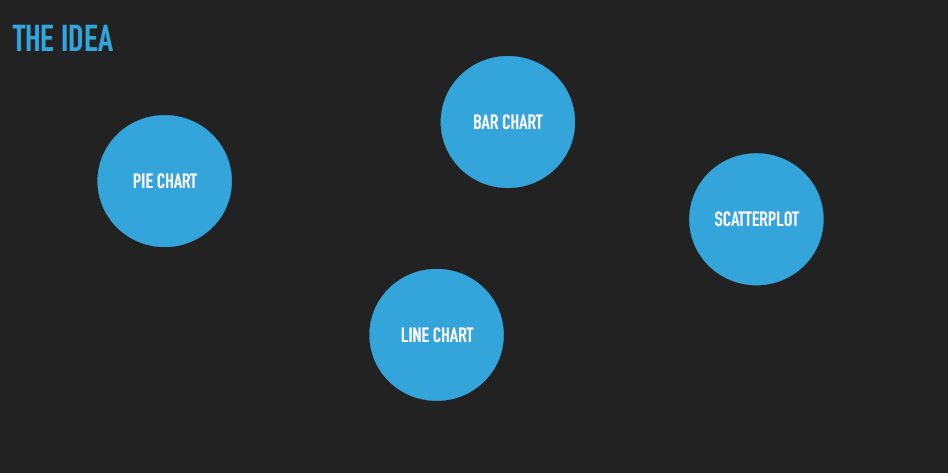

Thomas Lin Pedersen 2020 (celebRation2020)

## Compositional Logic

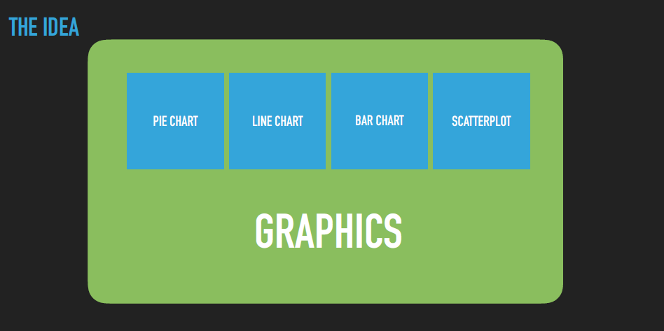

Thomas Lin Pedersen 2020 (celebRation2020)

## Compositional Logic

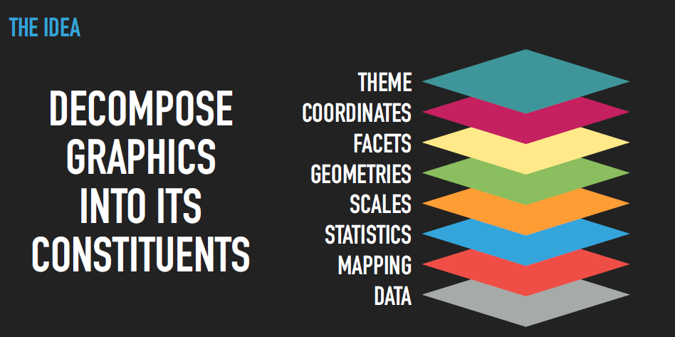

Thomas Lin Pedersen 2020 (celebRation2020)

## Compositional Logic

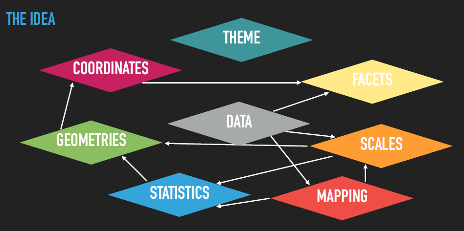

Thomas Lin Pedersen 2020 (celebRation2020)

## Compositional Logic

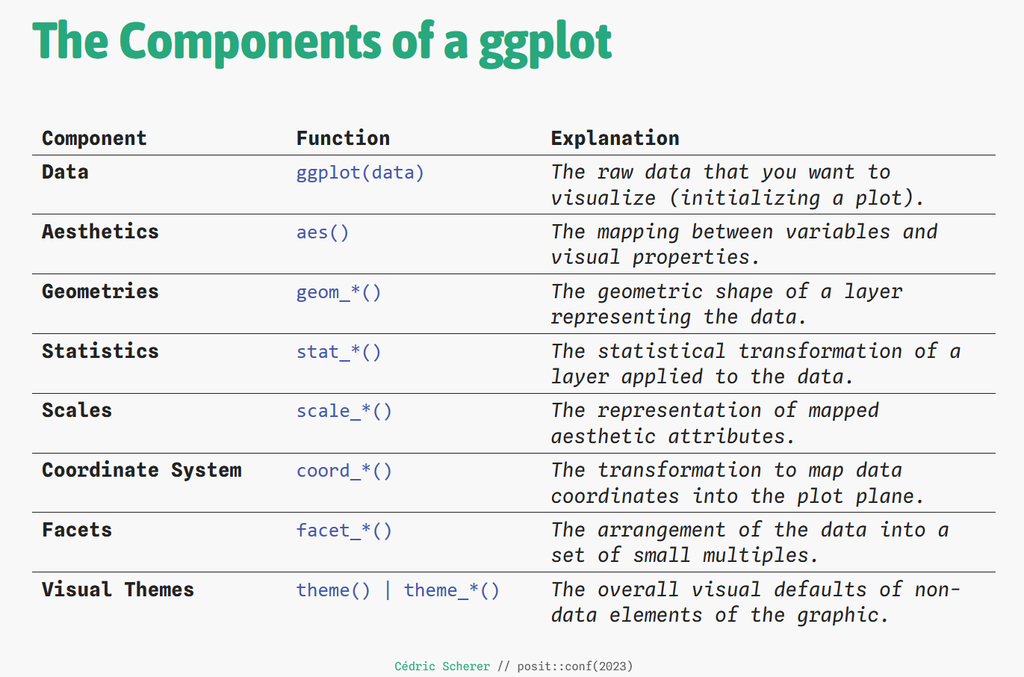

Cedric Scherer 2023 (Posit Conference)

## Data

- Overview
- Example
- Output
- your data for the plot
- in tidy format
- provides ingredients for your plot
- `tidyverse` techniques to prepare data for optimal plotting format
- one row for every observation that you want to plot

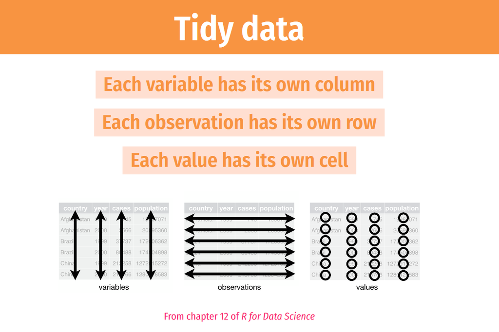

- [data set on bike sharing counts in London, TfL Open Data](https://tfl.gov.uk/modes/cycling/santander-cycles)
- covers the years 2015 and 2016
- weather data from freemeteo.com; prepared by Hristo Mavrodiev for [Kaggle](https://www.kaggle.com/hmavrodiev/london-bike-sharing-dataset) and [Cedric Scherer for Posit Conference 2023](https://posit-conf-2023.github.io/dataviz-ggplot2/modules/s01-fundamentals.html)

```r
library(readr)
library(ggplot2)

bikes <-
  read_csv("./slides_data/london-bikes.csv",
    col_types = "Dcfffilllddddc"
  )
```

$\rightarrow$ pass data to `ggplot`

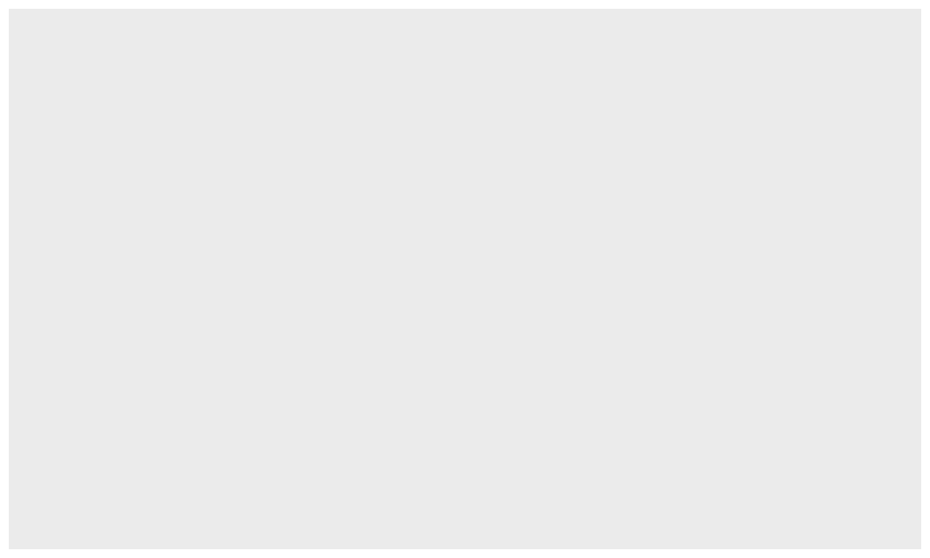

```r
ggplot(data = bikes)               # initial call + data
```

## Aesthetic Mapping

- Overview
- Cheat Sheet
- Example
- Output
- link variables in data to graphical properties in the geometry
- Aesthetics (aes), to make data visible
  - `x, y`: variable along the x and y axis
  - `colour`: color of geoms according to data
  - `fill`: the inside color of the geom
  - `group`: what group a geom belongs to
  - `shape`: the symbol used to plot a point
  - `linetype`: the type of line used (solid, dashed, etc)
  - `size`: size scaling for an extra dimension
  - `alpha`: the transparency of the geom

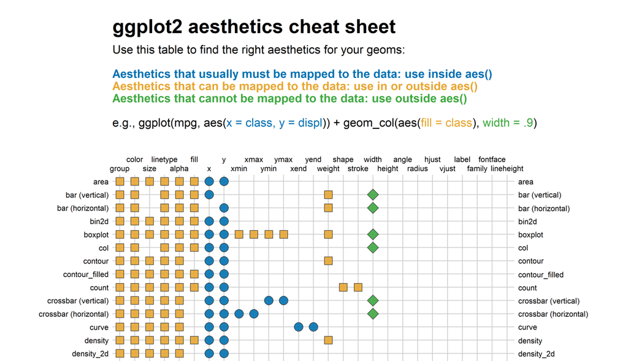

Christian Burkhart: https://drive.google.com/file/d/1Dvul1p6TYH6gWJzZRwpE0YX1dO0hDF-b/view

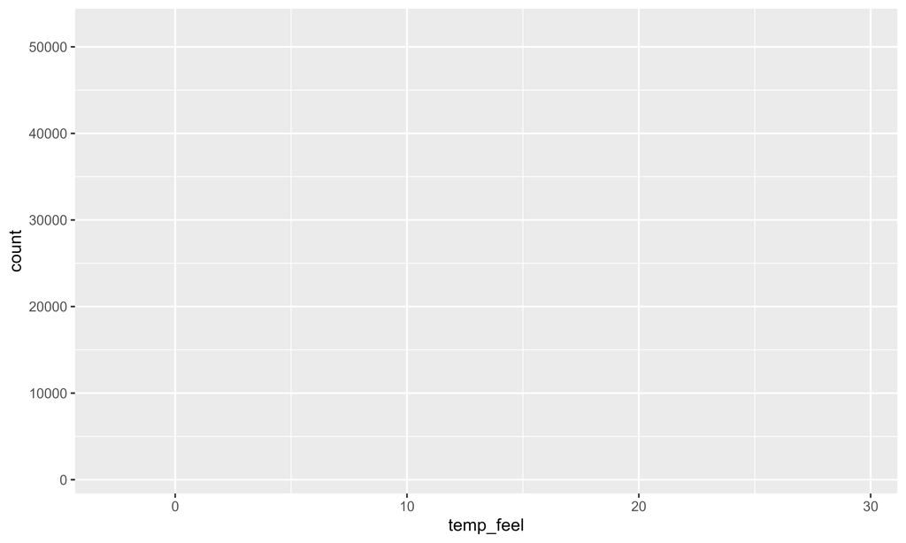

```r
# scatter plot of bikes$count versus bikes$temp_feel
ggplot(data = bikes) +              # initial call + data
  aes(x = temp_feel, y = count)     # aesthetics
```

## Geometries

- Overview
- Example
- Output
- how to interpret aesthetics as graphical representations
- determines to a large extent the type of plot
- some examples of geometries available in the ggplot2 framework
  - `geom_point()`: scatterplot
  - `geom_line()`: lines connecting points by increasing value of x
  - `geom_path()`: lines connecting points in sequence of appearance
  - `geom_boxplot()`: box and whiskers plot for categorical variables
  - `geom_bar()`: bar charts for categorical x axis
  - `geom_histogram()`: histogram for continuous x axis
  - `geom_violin()`: distribution kernel of data dispersion
  - `geom_smooth()`: function line based on data
- [each `geom_` is a shortcut for a function called `layer`](https://ggplot2-book.org/layers)

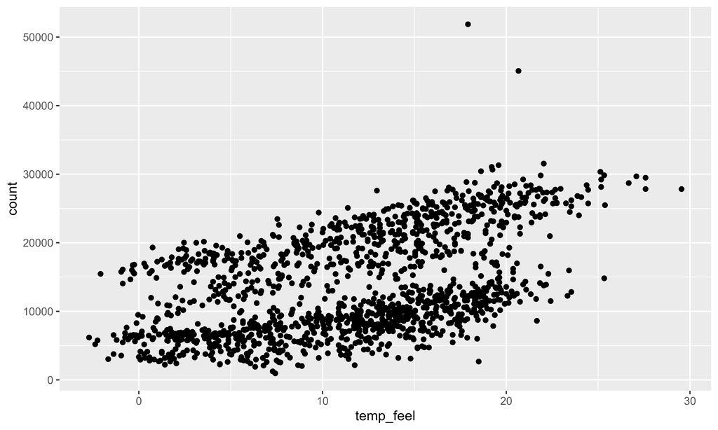

```r
# scatter plot of bikes$count versus bikes$temp_feel
ggplot(data = bikes) +              # initial call + data
  aes(x = temp_feel, y = count) +   # aesthetics
  geom_point()                      # geometric layer
```

## Statistics

- Overview
- Example
- Output
- even though data is tidy it may not represent the displayed values
- transform input variables to displayed values:
  - e.g., count number of observations in each category for a bar chart
  - e.g., calculate summary statistics for a boxplot
- implicit in many plot-types but can often be done prior to plotting
- linked to geometries
- every geom has a default stat(istic)
- layer can be created with a call to `stat_*()` or `geom_*()`
- latter is more frequently used in dataviz community
- pre-computed data: `stat = 'identity'`

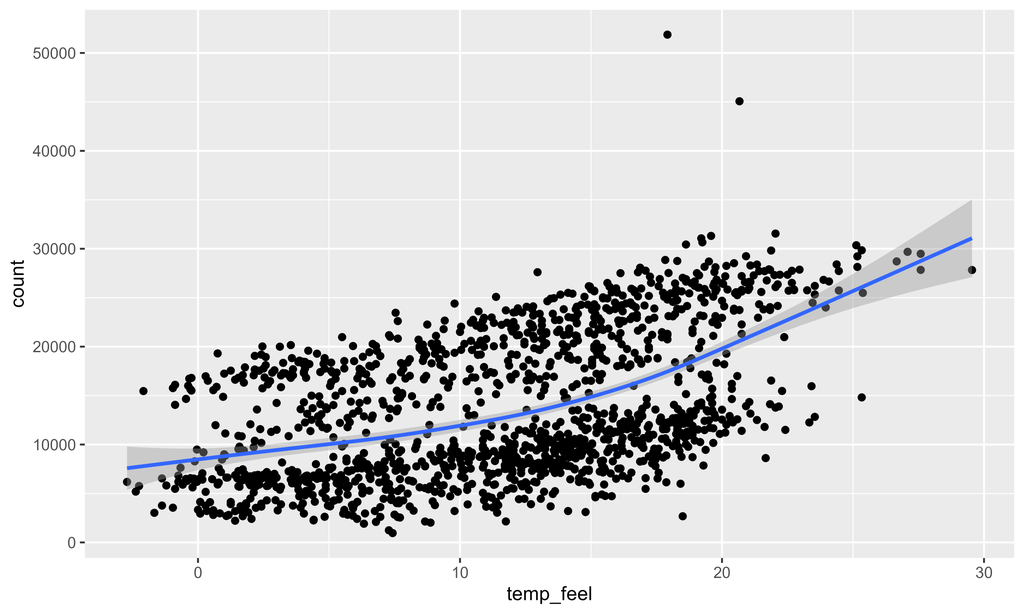

```r
ggplot(bikes,
       aes(x = temp_feel, y = count)) +
  geom_point() +
  # add a GAM smoothing
  stat_smooth() # also: geom_smooth()
```

## Scales

- Overview
- Example
- Output

$\rightarrow$ translate back and forth between variable ranges and property ranges

[**position scales**](https://ggplot2-book.org/scales-position)

- used to control locations of visual entities in a plot & and how locations are mapped to data values
- continuous scales (`scale_x_continuous`); special case of continuous scales: date scales (`scale_x_date`) vs. discrete position scales

[**colour scales**](https://ggplot2-book.org/scales-position)

- continuous color scales (`scale_fill_viridis_c()`; `scale_fill_distiller()`), discrete color scales (`scale_fill_viridis_d()`; `scale_fill_brewer()`)
- many other helpful R packages that provide color palettes (e.g., `paletteer` acting as a common interface for these different packages)

[**other scales**](https://ggplot2-book.org/scales-other)

- size, shape, line type, line width, manual scales, identity scales

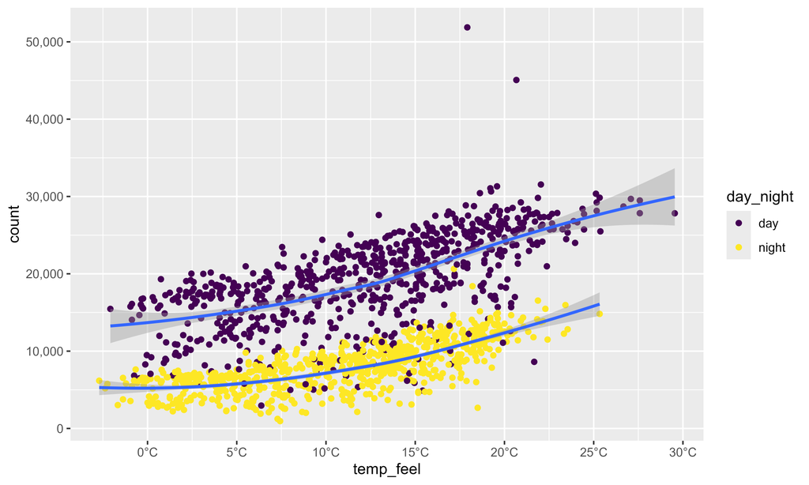

```r
ggplot(bikes, aes(x = temp_feel, y = count)) +
  # color mapping only applied to points
  geom_point(aes(color = day_night)) +
  # invisible grouping to create two trend lines
  stat_smooth(aes(group = day_night)) +
  scale_color_viridis_d() +
  # x axis
  scale_x_continuous(
    # add °C symbol
    labels = function(x) paste0(x, "°C"),
    # use 5°C spacing
    breaks = -1:6*5  # also: seq(-5, 30, by = 5)
  ) +
  # y axis
  scale_y_continuous(
    # add a thousand separator
    labels = scales::label_comma(),
    # use consistent spacing across rows
    breaks = 0:5*10000
  )
```

## Facets

- Overview
- Example 1: `facet_wrap`
- Output 1
- Example 2: `facet_grid`
- Output 2
- define the number of panels with equal logic and split data among them…
- small multiples
  - allows you to look at small subsets of your data in separate plots
  - panel layout may carry meaning
  - [`facet_wrap()` and `facet_grid()`](https://stackoverflow.com/questions/20457905/whats-the-difference-between-facet-wrap-and-facet-grid-in-ggplot2)
- should not be used to combine multiple separate plots
- ggplot2 provide two facets for splitting data by categories

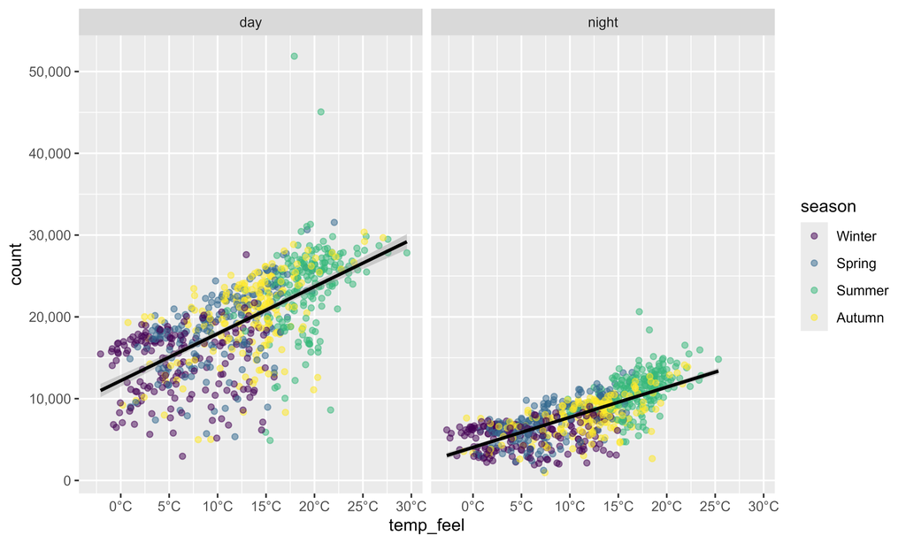

```r
ggplot(bikes, aes(x = temp_feel, y = count)) +
  geom_point(
    aes(color = season),
    alpha = .5, size = 1.5
  ) +
  stat_smooth(
    method = "lm", color = "black"
  ) +
  scale_color_viridis_d(
    # overwrite legend keys
    labels = c("Winter", "Spring", "Summer", "Autumn")
  ) +
  # x axis
  scale_x_continuous(
    # add °C symbol
    labels = function(x) paste0(x, "°C"),
    # use 5°C spacing
    breaks = -1:6*5  # also: seq(-5, 30, by = 5)
  ) +
  # y axis
  scale_y_continuous(
    # add a thousand separator
    labels = scales::label_comma(),
    # use consistent spacing across rows
    breaks = 0:5*10000
  ) +
  # small multiples
  facet_wrap(facets = vars(day_night)) # also: ~ day_night
```

```r
plot <- ggplot(bikes, aes(x = temp_feel, y = count)) +
  geom_point(
    aes(color = season),
    alpha = .5, size = 1.5
  ) +
  stat_smooth(
    method = "lm", color = "black"
  ) +
  scale_color_viridis_d(
    # overwrite legend keys
    labels = c("Winter", "Spring", "Summer", "Autumn")
  ) +
  # x axis
  scale_x_continuous(
    # add °C symbol
    labels = function(x) paste0(x, "°C"),
    # use 5°C spacing
    breaks = -1:6*5  # also: seq(-5, 30, by = 5)
  ) +
  # y axis
  scale_y_continuous(
    # add a thousand separator
    labels = scales::label_comma(),
    # use consistent spacing across rows
    breaks = 0:5*10000
  ) +
  facet_grid(
    rows = vars(day_night),
    cols = vars(year),
    # free y axis range
    scales = "free_y",
    # scale heights proportionally to length of y scale
    space = "free_y"
  ) +
  labs(
    # overwrite axis and legend titles
    x = "Average feels-like temperature", y = NULL, color = NULL,
    # add plot title and caption
    title = "Trends of Reported Bike Rents versus Feels-Like Temperature in London",
    caption = "Data: TfL (Transport for London), Jan 2015–Dec 2016"
  )
```

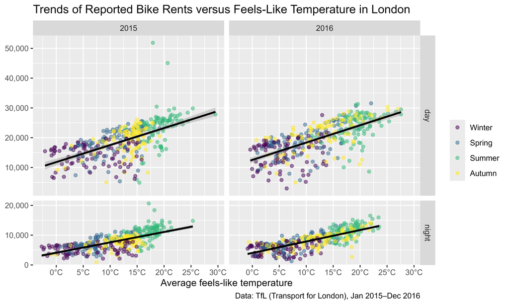